# Exploring the BRFSS data

## Setup

### Load packages

```r
library(ggplot2)
library(dplyr)
library(tidyverse)
```

### Load data

```r
load("brfss2013.Rdata")
```

## Part 1: Data

**Does the data use random sampling?**

The BRFSS does employ a form of random sampling since the probability of any adult family member answering the landline phone is the same. Initially, I thought people who don’t use telephones or don’t have landlines would be underrepresented and that this would introduce bias it the data set. However, after reading the study methodology on the CDC website I can see the Raking method they use for weighting adjusts for these problems.

**Does the data make use of random assignment?**

Since this is an observational study and no control, experiment groups exist. This study does not use random assignment. This also means that this data can help to illustrate association between different variables, but not causation.

## Part 2: Research questions

**Research question 1:** Are people diagnosed with COPD (Chronic obstructive pulmonary disease) likely to have smoked at least a 100 cigarettes?

*Why does it matter?*  
I have friends who smoke but believe it is alright since they don’t smoke ‘a lot.’ The aim here is to see if even smoking a relatively small number of cigarettes has any relation with serious health conditions such as COPD

**Research question 2:** Does the time spent walking and sleeping impact the general health of college age people (18 - 24Y)

*Why does it matter?*  
I’m a college student who is very fond of walking and regularly sacrifices sleep. I’m certain I’m not alone.

**Research question 3:**  
How does feeling of worthlessness vary among people of different employmnent status (students, retirees, employed for wages and homemakers) and is this feeling related to annual household income?

*Why does it matter?*  
I’m about to graduate and it would be interesting to see if people derive a sense of worth from their work more than students do from their studies.

## Part 3: Exploratory data analysis

**Research question 1:**  
First we choose the data relevant to our question. We drop all samples that didn’t answer the relevant questions and convert the two relevant cases to factors.

```r
req_data <- brfss2013 %>%
  select(smoke100, chccopd1,sex, X_age80) %>%
  mutate(chccopd100 = case_when(
    smoke100 == 'Yes' & chccopd1 == 'Yes' ~ 'Has COPD and smoker',
    smoke100 == 'No' & chccopd1 == 'Yes' ~ 'Has COPD and non-smoker ')) %>%
  na.omit() %>%
  mutate(chccopd100 = as.factor(chccopd100))
```

If we work out the statistics of this data, we will get a high level overview of the profile of the average COPD patient.

```r
req_data %>%
  group_by(chccopd100, sex) %>%
  summarise(count=n(), avg_age=round(mean(X_age80)))
```

```
## # A tibble: 4 × 4
## # Groups:   chccopd100 [2]
##   chccopd100                 sex    count avg_age
##   <fct>                      <fct>  <int>   <dbl>
## 1 "Has COPD and non-smoker " Male    2293      59
## 2 "Has COPD and non-smoker " Female  7318      63
## 3 "Has COPD and smoker"      Male   11579      63
## 4 "Has COPD and smoker"      Female 18412      62
```

We see that the people diagnosed with COPD who were also smokers are nearly two-thirds female with an average age of  
62 and one-third male with an average age of 63. The total people that have COPD and smoked more than a hundred cigarettes during  
their lifetimes are 29,991 out of 39,602 total COPD cases. A graphical depiction of this finding is below:

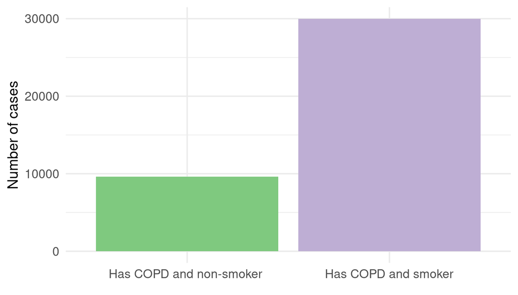

```r
ggplot(data=req_data, width=2) +
  geom_bar(aes(x = chccopd100, fill=chccopd100), position = 'dodge',
           stat = 'count') +
  scale_fill_brewer(type='qualitative', palette = 'Accent') +
  labs(x=element_blank(), y = 'Number of cases') +
  theme_minimal(base_size = 14) +
  theme(legend.position = 'none', axis.text.x=element_text(size = 12),
        axis.text.y=element_text(size=12))
```

We’ve seen the average profile of a person afflicted with COPD in the survey. We also see that the vast majority of these people have smoked at least a hundred cigarettes.  
This hints at a potential link between smoking and COPD. However, it is important to note that the overall brfss2013 data set is heavily skewed towards people that don’t have COPD and the number of people who have smoked more than a hundred cigarettes and still don’t have COPD is very large as shown by the table below:

```r
brfss2013 %>%
  select(smoke100, chccopd1, X_age80) %>%
  mutate(smoker_non_copd = ifelse((smoke100=='Yes' & chccopd1=='No'),'No COPD and smoker',NA)) %>%
  mutate(smoker_non_copd = as.factor(smoker_non_copd)) %>%
  group_by(smoker_non_copd) %>%
  na.omit() %>%
  summarise(count = n(), avg_age=round(mean(X_age80)))
```

```
## # A tibble: 1 × 3
##   smoker_non_copd     count avg_age
##   <fct>               <int>   <dbl>
## 1 No COPD and smoker 183786      56
```

One thing to notice here is that the average age of people who smoke but haven’t developed COPD is significantly lower than those that have. This suggests that there may be a link between smoking and developing COPD, even if the onset of the disease is in older age.

**Research question 2:**  
We first retrieve the data of our interest by filtering by activity and age and selecting the relevant columns. We also perform some pre-processing on the exercise columns and combine them to find the number of minutes spent walking per week, which is represented by ‘exermin_perweek’

```r
req_data2 <- brfss2013 %>%
  filter((X_age80 >= 18 & X_age80 <= 24) & (exract11 == 'Walking')) %>%
  select(sleptim1, exeroft1, exerhmm1, genhlth) %>%
  na.omit() %>%
  mutate(exeroft1_weekly = if_else(exeroft1 >= 200, ceiling((exeroft1 - 200)/4), exeroft1-100)) %>%
  mutate(exerhmm1_min = if_else(exerhmm1 >= 100, 60*floor(exerhmm1/100)+100*((exerhmm1/100)%%1),
                                as.double(exerhmm1))) %>%
  mutate(exermin_perweek = (round(exeroft1_weekly*exerhmm1_min)))
```

We then determine the average number of hours of sleep and the median number of minutes spent walking per week by our chosen demographic against their self - reported health condition. We choose the median for ‘time spent walking’ because it is a robust statistic and calculating the mean gives vastly higher values, which is probably because of extreme outliers.  
We stick with using mean in ‘sleep time’ because the median and mean of that column are fairly similar, indicating that there are no significant outliers in this case.

```r
summary_stats2 <- req_data2 %>%
  group_by(genhlth) %>%
  summarise(count = n(), avg_sleep = mean(sleptim1), median_exermin_wk=median(exermin_perweek))
summary_stats2
```

```
## # A tibble: 5 × 4
##   genhlth   count avg_sleep median_exermin_wk
##   <fct>     <int>     <dbl>             <dbl>
## 1 Excellent  1123      7.39               180
## 2 Very good  2135      7.21               180
## 3 Good       1958      7.14               150
## 4 Fair        512      6.66               175
## 5 Poor         77      6.29               240
```

We see that people who report being in excellent shape sleep more than 7 hours and spend about 3 hours per week walking. The differences between this group and other groups are illustrated in the two bar plots below.

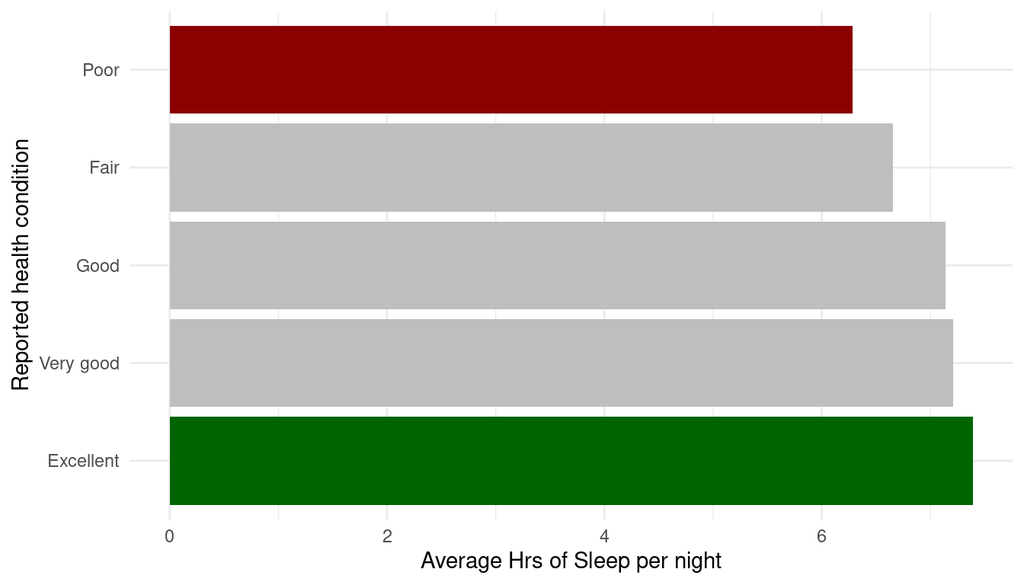

```r
ggplot(data = summary_stats2, aes(x=genhlth, y=avg_sleep, fill=genhlth)) +
  geom_col() +
  coord_flip() +
  theme_minimal() +
  scale_fill_manual("legend", values = c("Poor" = "dark red", "Excellent" = "dark green",
                                         "Good" = 'gray','Very good'='gray',
                                         'Fair'='gray')) +
  theme(legend.position = 'none') +
  labs(x='Reported health condition', y='Average Hrs of Sleep per night')
```

We see here that people with excellent health sleep more than 7 hours per night. The next 2 categories report fairly similar numbers, then we see a larger decline in the ‘fair’ and ‘poor’ categories, with people in the ‘poor’ category reporting the lowest sleep times (around 6 hours).

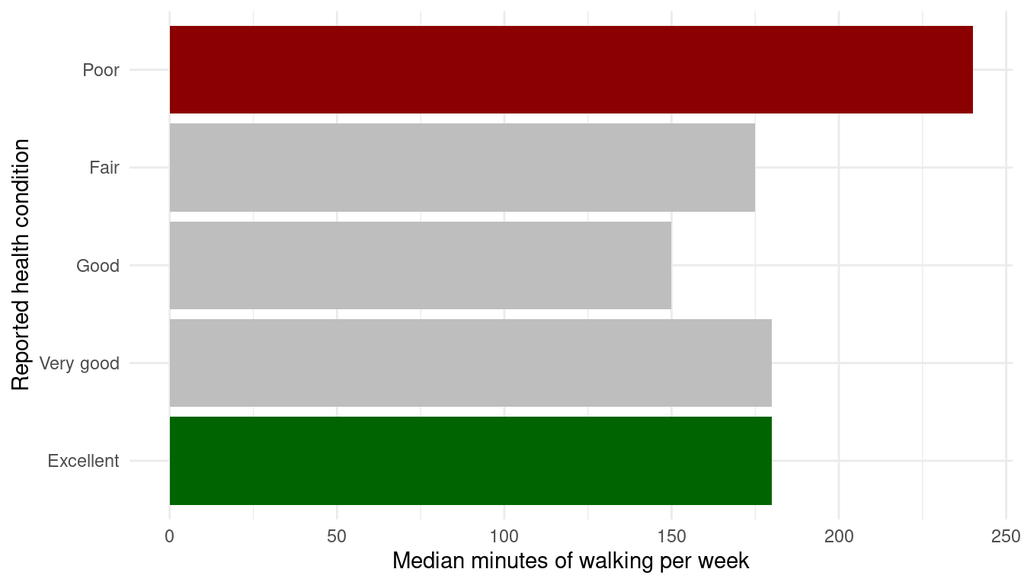

```r
summary_stats2 %>%
  ggplot(aes(x=median_exermin_wk, y=genhlth, fill=genhlth)) +
  geom_col() +
  theme_minimal() +
  scale_fill_manual("legend", values = c("Poor" = "dark red", "Excellent" = "dark green",
                                         "Good" = 'gray','Very good'='gray',
                                         'Fair'='gray')) +
  theme(legend.position = 'none') +
  labs(y='Reported health condition', x='Median minutes of walking per week')
```

In general, we see that people who report their physical and mental health as ‘poor’ tend to be those that sleep the least  
(roughly 6 hours) and also exert the most (walking 4 hours per week against 3 hours for the ‘Excellent’ category)

**Research question 3:**  
We’ll start off, as always, by pulling out the data relevant to our question.

```r
req_data3 <- brfss2013 %>%
  select(employ1, income2, miswtles) %>%
  na.omit() %>%
  filter(employ1 == 'A student' | employ1 == 'A homemaker' | employ1 == 'Retired'
         | employ1 == 'Employed for wages') %>%
  droplevels()
```

Let’s get a quick look at what sort of data we have:

```r
req_data3 %>%
  group_by(miswtles) %>%
  summarise(count  =n())
```

```
## # A tibble: 5 × 2
##   miswtles count
##   <fct>    <int>
## 1 All        119
## 2 Most       157
## 3 Some       717
## 4 A little  1323
## 5 None     22460
```

We see that the vast majority of people in our data set report not feeling worthless even once a month. Let’s remove these cases and take a closer look at the rest

```r
req_data3 <- req_data3 %>%
  filter(miswtles != 'None') %>%
  droplevels()
```

```r
req_data3 %>%
  group_by(miswtles, employ1, .add = TRUE) %>%
  summarise(count = n())
```

```
## # A tibble: 16 × 3
## # Groups:   miswtles [4]
##    miswtles employ1            count
##    <fct>    <fct>              <int>
##  1 All      Employed for wages    43
##  2 All      A homemaker           10
##  3 All      A student              4
##  4 All      Retired               62
##  5 Most     Employed for wages    66
##  6 Most     A homemaker           13
##  7 Most     A student              8
##  8 Most     Retired               70
##  9 Some     Employed for wages   379
## 10 Some     A homemaker           57
## 11 Some     A student             32
## 12 Some     Retired              249
## 13 A little Employed for wages   766
## 14 A little A homemaker          106
## 15 A little A student             50
## 16 A little Retired              401
```

Let’s take a look at the income breakdown of these categories. For simplicity, we’re going to collapse the current income groups into four, namely: ‘Less than $25K’, ‘Less than $50K’, ‘Less than $75K’, ‘More than $75,000’ and rename them to something more concise.

```r
req_data3$income2 <- fct_collapse(req_data3$income2,  '<25K' = c('Less than $10,000','Less than $15,000','Less than $20,000',
                                                 'Less than $25,000'),
               '<50K' = c('Less than $35,000','Less than $50,000'),
               '<75K' = c('Less than $75,000'),
               '>75K' = c('$75,000 or more'))
```

A high level view of the distribution with respect to income and employment can be seen in the table below:

```r
table(req_data3$employ1, req_data3$income2, req_data3$miswtles)
```

```
## , ,  = All
##
##
##                      <25K <50K <75K >75K
##   Employed for wages   21   11    5    6
##   A homemaker           9    1    0    0
##   A student             3    1    0    0
##   Retired              37   17    3    5
##
## , ,  = Most
##
##
##                      <25K <50K <75K >75K
##   Employed for wages   29   24    9    4
##   A homemaker           8    1    1    3
##   A student             5    3    0    0
##   Retired              38   17   12    3
##
## , ,  = Some
##
##
##                      <25K <50K <75K >75K
##   Employed for wages  100  108   78   93
##   A homemaker          23   16    4   14
##   A student            19    8    3    2
##   Retired             139   70   21   19
##
## , ,  = A little
##
##
##                      <25K <50K <75K >75K
##   Employed for wages  150  219  150  247
##   A homemaker          43   30   13   20
##   A student            32    6    6    6
##   Retired             174  138   54   35
```

We see that feelings of worthlessness decrease as we move up the income bracket. This is the case for the ‘All’ and ‘Most’ category. For the milder ‘Some’ and ‘little’ categories the income level becomes more or less irrelevant.

The facet bar graph below illustrates all these relationships together:

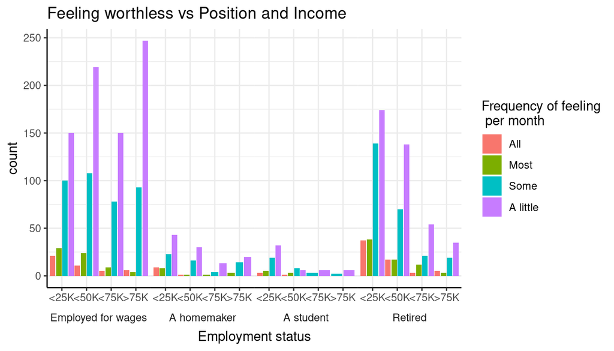

```r
req_data3 %>%
  ggplot(aes(income2, fill=miswtles), position_dodge(width = 1)) +
  geom_bar(position=position_dodge(width = 1)) +
  facet_grid(.~employ1, switch = 'x') +
  theme_bw() +
  theme(strip.placement = "outside",
        strip.background = element_blank(),
        panel.border = element_blank(),
        panel.spacing = unit(0, "points"),
        axis.line = element_line()) +
  labs(title = 'Feeling worthless vs Position and Income',  x='Employment status',
       fill= 'Frequency of feeling\n per month')
```

All in all, we can see that all people regardless of employment status suffer from feelings of worthlessness every month. However, the severity of these feelings is particularly pronounced in the retirees, and then salaried people. People with higher incomes tend to feel worthless less frequently but income level doesn’t seem to have a reciprocal relationship with frequency of feeling.